# Predicting Seasonal Influenza

June 28, 2020

### **Introduction**

**Disclaimer**

The current influenza epidemiological data should be interpreted with caution as the ongoing COVID-19 pandemic might have influenced to different extents human behaviors, medical staffing procedures, as well as testing capacities at the state level. The various COVID-19 response measures to reduce SARS-CoV2 virus transmission may have an impact on influenza virus transmission within the U.S.

### **Dataset Description**

**Data Source:** World Health Organization  
**Time Period:** January 4, 2016 - May 31, 2020  
**Interval:** weekly  
**Measurement:** Number of positive flu Type A cases

**website:**  
https://www.who.int/influenza/surveillance_monitoring/updates/latest_update_GIP_surveillance/en/

### **Exploratory Data Analysis Section**

Time Series Realization Plots:

Let us first look at the time series to determine whether we need to transform the data.

**Standard Realization Plot of Original Data**

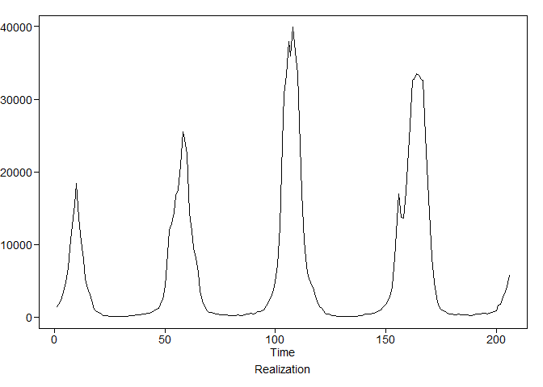

```r
plotts.wge(x)
```

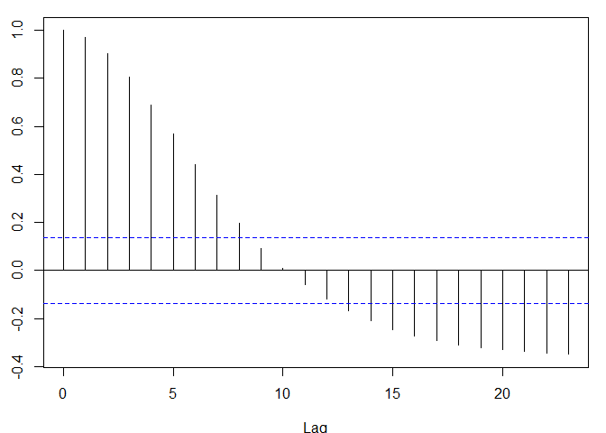

```r
acf(x)
```

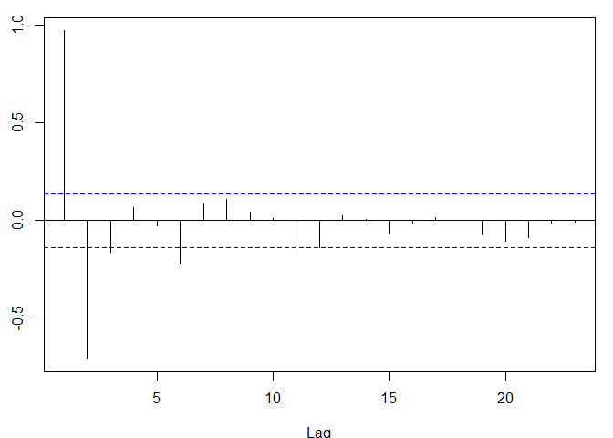

```r
pacf(x)
```

Important observations to point out:  
. The data clearly exhibits a seasonal pattern  
. There is a slight consistent upward “linear” trend  
. The amplitude of the seasonal cycle increases over time

Note, the problem of an increasing amplitude can often be overcome by applying a log transformation

### **Transformation Process**

Step 1: Review distirbution to determine whether if a log transformation of the data is required.

The purposes of using a transformation are primarily to decouple the mean and the variance so that the variability is more or less constant and does not depend on the mean, ensure that the model is additive and relatively simple, and that the residuals, after fitting the model, are more or less normally distributed with zero mean and constant variance.

**Review of Original Data**

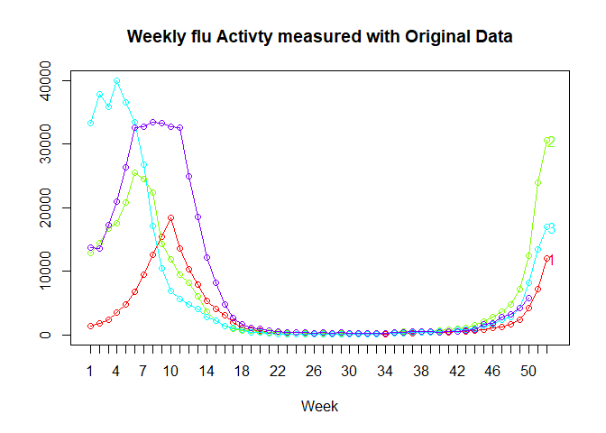

```r
seasonplot(x, 52, col=rainbow(4), year.labels=TRUE, season.labels =TRUE,  main="Weekly flu Activty measured with Original Data")
```

**Review of transformed data**

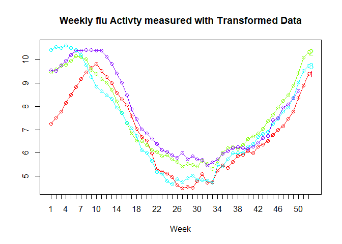

```r
x <- log(x)
x_original <- log(x_original)
seasonplot(x, 52, col=rainbow(4), year.labels=TRUE, season.labels =TRUE,  main="Weekly flu Activty measured with Transformed Data")
```

Taking the log of X appears to have improved the distribution. Now lets take another look at the time realization plots.

**Standard Realization Plot using transformed data**

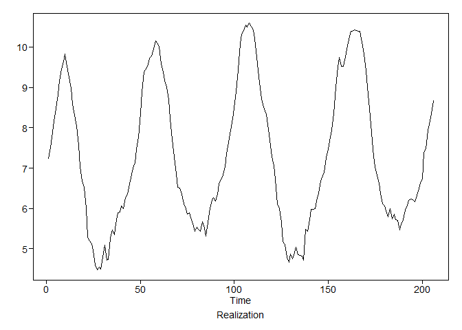

```r
plotts.wge(x)
```

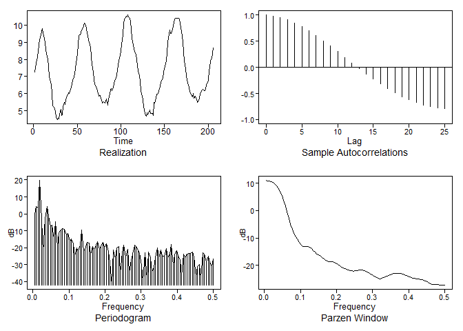

[output not shown]

[output cut: 51 more lines]

```r
plotts.sample.wge(x)
```

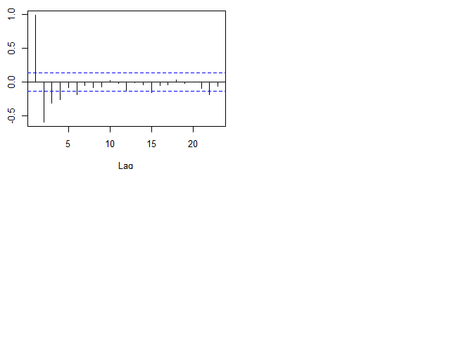

```r
pacf(x)
```

Observations:  
The ACF shows a large number of positive autocorrelations out to a very high number of lags, suggesting as a minimum, a first difference is required.

Step 2: Determine optimal order of differencing

```r
d1.x=artrans.wge(x,phi.tr=1)
```

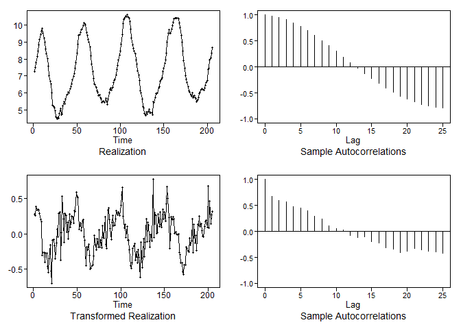

Observations:  
The ACF continues to exhibit a persistent autocorrelation pattern, indicating the need for a seasonal differencing.

Step 3: Remove Seasonal differencing

While it is believed that a need for seasonal differencing is required, we do not want to overdifference the model. Therefore, we will perform a Dicky Fuller Test to see if our time series requires additional differencing.

Dicky Fuller Test:  
the Dickey-Fuller test tests the null hypothesis that a unit root is present in an autoregressive model. For stationarity confirmation, We want to REJECT the null hypothesis for this test and therefore acheive a p-value of less that 0.05 (or smaller).

```r
adf.test(d1.x)
```

```
##
##  Augmented Dickey-Fuller Test
##
## data:  d1.x
## Dickey-Fuller = -2.9729, Lag order = 5, p-value = 0.1684
## alternative hypothesis: stationary
```

Based on the Dicky Fuller Test, the pvalue is greater than 0.05 and therefore we do not reject the null hypothesis that the data is non-stationary.

To remove the non-stationarity, we need to take the seasonal difference of the data and then retake the Dicky Fuller Test to see if we were successful.

```r
d2.x=artrans.wge(d1.x,c(rep(0,51),1))
```

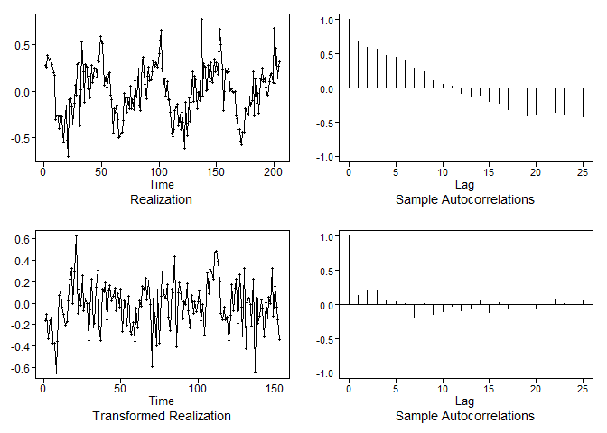

CONFIRM STATIONARITY

Steps: 1. Perform visual checks to confirm that all the stationarity conditions have been met. 2. Run Dicky Fuller Test for additional confirmation.

Step 1: Utilize the Time Realizations, Sample Autocorrelations, & Parzen Plots generated below to review the stationarity of new time series.

**Time Realization, Sample Autocorrelation, & Parzen Plots**

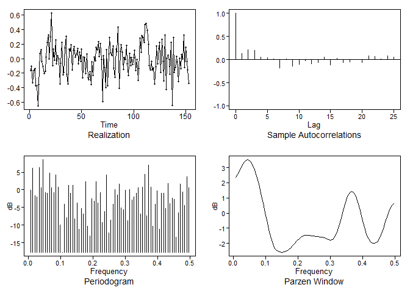

[output not shown]

[output cut: 40 more lines]

```r
#Time Series under review: d2.x
# Determine periodicity range
n <-length(d2.x)
n1 <- n/2
n2 <- n1+1

# Plots related to Conditions 1 & 2
plotts.sample.wge(d2.x)
```

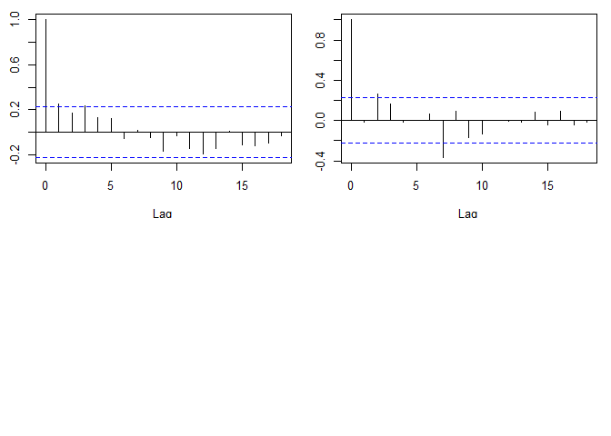

```r
#Plots related to Conditions 2 & 3
# First Half of Data-ACF
acf(d2.x[1:n1])
# Second Half of Data-ACF
acf(d2.x[n2:n])
```

Confirm stationarity review by running a Dicky Fuller Test:

```r
adf.test(d2.x)
```

```
##
##  Augmented Dickey-Fuller Test
##
## data:  d2.x
## Dickey-Fuller = -4.3154, Lag order = 5, p-value = 0.01
## alternative hypothesis: stationary
```

Interpretations:

All three conditions appear to be met. Data is stationary. We can now move on the the model selection process.

### **Time Series Historical Trend Review**

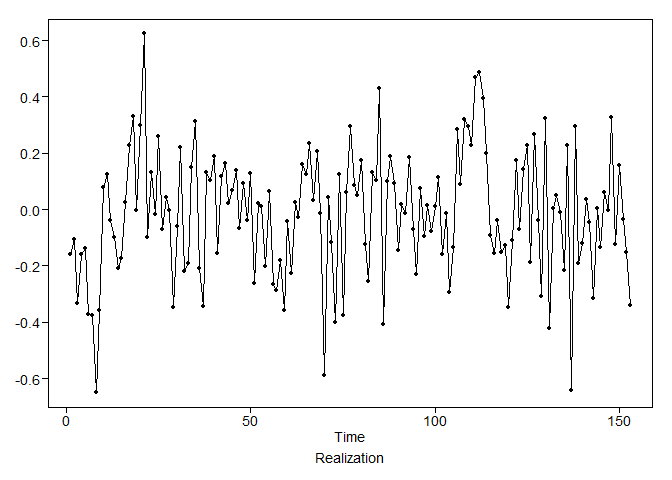

```r
plotts.wge(d2.x)
```

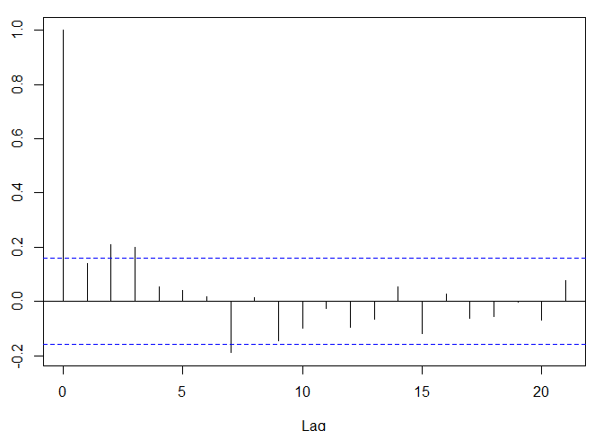

```r
acf(d2.x)
```

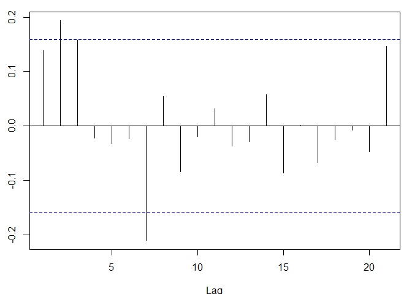

```r
pacf(d2.x)
```

### **MODEL SELECTION PROCESS**

Now that data appears stationary, run AIC5 to determine optimal P&Q based on AIC & BIC

##### AIC5 Stationary data (d2.x) results for AIC measure:

```r
aic5.wge(d2.x, p=0:5, q=0:2)
```

```
## ---------WORKING... PLEASE WAIT...
##
##
## Five Smallest Values of  aic
```

```
##       p    q        aic
## 10    3    0  -3.032584
## 6     1    2  -3.028147
## 8     2    1  -3.020932
## 13    4    0  -3.019900
## 11    3    1  -3.019788
```

##### AIC5 X Data results for BIC measure:

```r
aic5.wge(d2.x, p=0:5, q=0:2, type="bic")
```

```
## ---------WORKING... PLEASE WAIT...
##
##
## Five Smallest Values of  bic
```

```
##       p    q        bic
## 1     0    0  -2.964899
## 7     2    0  -2.958586
## 5     1    1  -2.956428
## 10    3    0  -2.953357
## 4     1    0  -2.951943
```

### PARAMETER ESTIMATION

```r
#define model 1 p, d, q estimates:
p=3
q=0

ARIMA_m1 = est.arma.wge(d2.x, p=p, q=q)
```

```
##
## Coefficients of Original polynomial:
## 0.0826 0.1787 0.1622
##
## Factor                 Roots                Abs Recip    System Freq
## 1-0.6868B              1.4561               0.6868       0.0000
## 1+0.6041B+0.2362B^2   -1.2788+-1.6119i      0.4860       0.3567
##
##
```

Now that we have fit the model. Lt us check the residuals for white noise before proceeding any further.

### RESIDUAL CHECKS

Step 1: Visual Check of Residual Sample Correlations

Lets us look at the residuals to see if they visually to see if behavior resembles white noise:

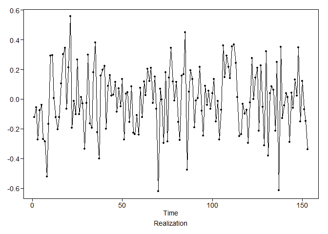

```r
plotts.wge(ARIMA_m1$res)
```

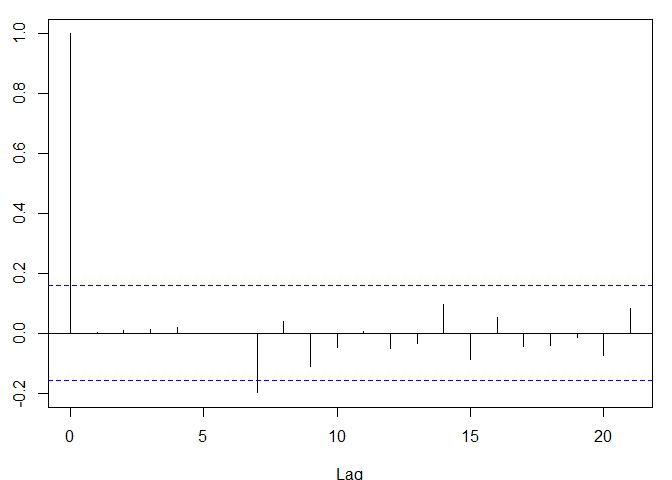

```r
acf(ARIMA_m1$res)
```

Step 2: Ljung-Box test for k=24 and K= 48

Let’s run the lJung-Box test for k=24 to determine the significance

Ljung-Box test for k=24:

```r
ljung.wge(ARIMA_m1$res,p=p)
```

```
## Obs 0.002231011 0.01022527 0.01258812 0.02062335 0.0003914304 -0.00161391 -0.1982922 0.03996014 -0.1095672 -0.04717457 0.006989968 -0.05118778 -0.03328684 0.09753212 -0.08680298 0.05137828 -0.0437002 -0.04169488 -0.01259052 -0.07503356 0.08233752 0.06860816 0.01102514 0.08737511
```

```
## $test
## [1] "Ljung-Box test"
##
## $K
## [1] 24
##
## $chi.square
## [1] 18.28183
##
## $df
## [1] 21
##
## $pval
## [1] 0.6311061
```

Observations:  
L Jung Box Test did not reject the null hypothesis of white noise at K=24 with p-value of .63

Let’s run the lJung-Box test for k=48 to determine the significance.

Ljung-Box test for k=48:

```r
ljung.wge(ARIMA_m1$res,p=p,K=48)
```

```
## Obs 0.002231011 0.01022527 0.01258812 0.02062335 0.0003914304 -0.00161391 -0.1982922 0.03996014 -0.1095672 -0.04717457 0.006989968 -0.05118778 -0.03328684 0.09753212 -0.08680298 0.05137828 -0.0437002 -0.04169488 -0.01259052 -0.07503356 0.08233752 0.06860816 0.01102514 0.08737511 0.05678877 -0.093…
```

```
## $test
## [1] "Ljung-Box test"
##
## $K
## [1] 48
##
## $chi.square
## [1] 42.32258
##
## $df
## [1] 45
##
## $pval
## [1] 0.5860224
```

Observations:  
L Jung Box Test did not reject the null hypothesis of white noise at K=48 with p-value of .58.

#### Conclusion of Residual Checks:

Based on the visual sample correlation plots and the L Jung-Box Tests, the residuals from the fitted model appear to be white.

### Model Validation

```r
# Set forecast window - nlook ahead periods
f <- 13

x_test <- x_original[nf:n0]


#Confirm variable definitions:
phi <- ARIMA_m1$phi
vara <- ARIMA_m1$avar
theta <- ARIMA_m1$theta
d <- 1
s <- 52

#Run Forecast
fm1 =fore.aruma.wge(x, phi=phi, theta=theta, d=d, s=s, n.ahead=f,limits=TRUE)
```

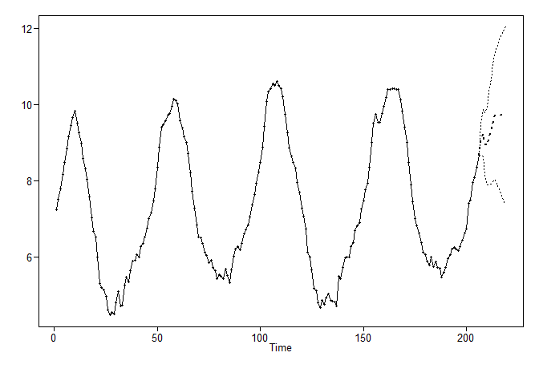

```r
fm1
```

```
## $f
##  [1] 9.097202 9.237482 8.955773 8.916269 9.117911 9.292871 9.512185 9.710915
##  [9] 9.711121 9.728439 9.720618 9.701581 9.694858
##
## $ll
##  [1] 8.676420 8.617333 8.137649 7.893052 7.910598 7.912062 7.968424 8.015241
##  [9] 7.872496 7.755015 7.619672 7.479473 7.357264
##
## $ul
##  [1]  9.517983  9.857632  9.773898  9.939487 10.325223 10.673680 11.055946
##  [8] 11.406588 11.549745 11.701863 11.821565 11.923688 12.032452
##
## $resid
##   [1]  0.000000000  0.000000000  0.000000000  0.000000000  0.000000000
##   [6]  0.000000000  0.000000000  0.000000000  0.000000000  0.000000000
```

[output cut: 66 more lines]

#### ASE Model Forecast

```r
#Determine ASE
fm1.ASE = mean((x_test - fm1$f)^2)
fm1.ASE
```

```
## [1] 0.3202319
```

#### Model Forecast Results - Time Realization Plot

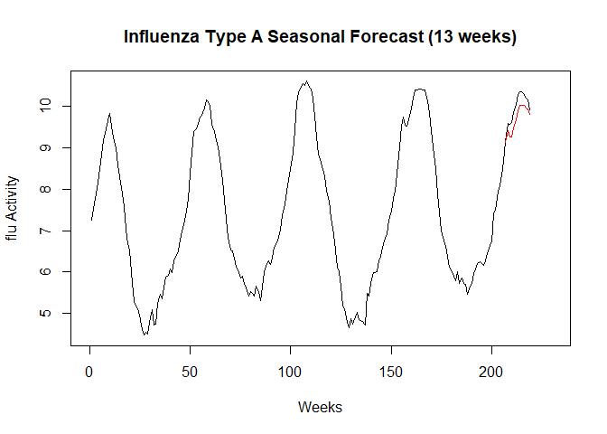

```r
#We have predicted differences .... calculate actual results
Model_Forecast1 =(x_test + fm1$f)/2

#Plot
plot(seq(1,n0,1), x_original, type="l", xlim = c(0,230), xlab= "Weeks", ylab = "flu Activity", main = "Influenza Type A Seasonal Forecast (13 weeks)")
lines(seq(nf,n0,1), Model_Forecast1, type = "l", col = "red")
```

#### Plot Comparisons: Predicted Vs. Realization Time Series

#### Compare Spectral Densities:

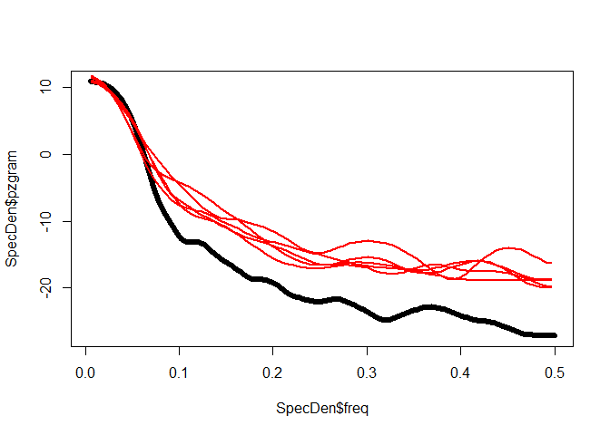

```r
sims = 5
SpecDen = parzen.wge(x, plot = "FALSE")
plot(SpecDen$freq,SpecDen$pzgram, type = "l", lwd = 6)

for( i in 1: sims)
{
  SpecDen2 = parzen.wge(gen.aruma.wge(n, phi=phi, s=s, d=d, plot = "FALSE"), plot = "FALSE")
  lines(SpecDen2$freq,SpecDen2$pzgram, lwd = 2, col = "red")
}
```

#### Compare ACF’s:

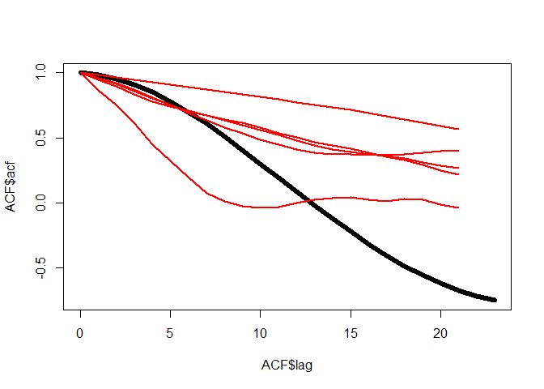

```r
sims = 5
ACF = acf(x, plot = "FALSE")
plot(ACF$lag ,ACF$acf , type = "l", lwd = 6)

for( i in 1: sims)
{
  ACF3 = acf(gen.aruma.wge(n, phi=phi, s=s, d=d, plot = "FALSE"), plot = "FALSE")
  lines(ACF3$lag ,ACF3$acf, lwd = 2, col = "red")
}
```

Compare Predicted Vs. Actual Time Series over the 13 week forecast period:

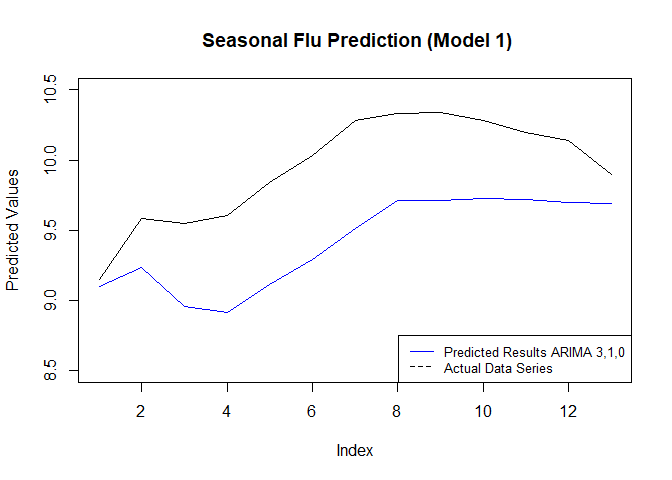

```r
name1 <- "Predicted Results ARIMA 3,1,0"
value1 <- fm1$f


color1 <-"Blue"


plot(x_test, type="l",
     xlim= c(1,13), ylim = c(8.5,10.5),
     ylab= "Predicted Values",
     main= " Seasonal Flu Prediction (Model 1)")
lines(seq(1,f), value1, col=color1)

# Add a legend
legend("bottomright", legend=c(name1, "Actual Data Series"),
       col=c(color1, "black"), lty=1:2, cex=0.8)
```

### PARAMETER ESTIMATION

```r
#define model 1 p, d, q estimates:
p2=2
q2=0

ARIMA_m2 = est.arma.wge(d2.x, p=p2, q=q2)
```

```
##
## Coefficients of Original polynomial:
## 0.1142 0.1957
##
## Factor                 Roots                Abs Recip    System Freq
## 1-0.5032B              1.9874               0.5032       0.0000
## 1+0.3890B             -2.5710               0.3890       0.5000
##
##
```

Now that we have fit the model. Let us check the residuals for white noise before proceeding any further.

### RESIDUAL CHECKS

Step 1: Visual Check of Residual Sample Correlations

Lets us look at the residuals to see if they visually to see if behavior resembles white noise:

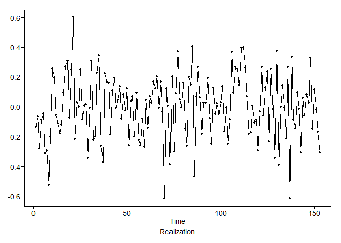

```r
plotts.wge(ARIMA_m2$res)
```

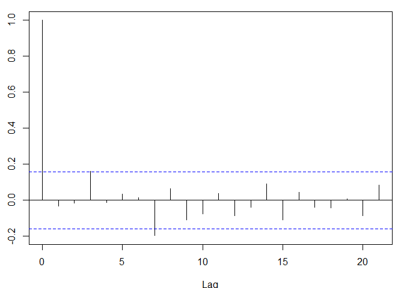

```r
acf(ARIMA_m2$res)
```

Step 2: Ljung-Box test for k=24 and K= 48

Let’s run the lJung-Box test for k=24 to determine the significance

Ljung-Box test for k=24:

```r
ljung.wge(ARIMA_m2$res,p=p2)
```

```
## Obs -0.03136765 -0.01464587 0.1613236 -0.01076951 0.0358071 0.01606533 -0.1956244 0.06456653 -0.1068337 -0.07570425 0.03691968 -0.08582695 -0.03874548 0.09173707 -0.109377 0.04587371 -0.03859672 -0.04205254 0.006614049 -0.08380282 0.08301204 0.06892059 -0.0238192 0.08943544
```

```
## $test
## [1] "Ljung-Box test"
##
## $K
## [1] 24
##
## $chi.square
## [1] 25.37448
##
## $df
## [1] 22
##
## $pval
## [1] 0.2795041
```

Observations:  
L Jung Box Test did not reject the null hypothesis of white noise at K=24 with p-value of .27.  
Let’s run the lJung-Box test for k=48 to determine the significance

Ljung-Box test for k=48:

```r
ljung.wge(ARIMA_m2$res,p=p2,K=48)
```

```
## Obs -0.03136765 -0.01464587 0.1613236 -0.01076951 0.0358071 0.01606533 -0.1956244 0.06456653 -0.1068337 -0.07570425 0.03691968 -0.08582695 -0.03874548 0.09173707 -0.109377 0.04587371 -0.03859672 -0.04205254 0.006614049 -0.08380282 0.08301204 0.06892059 -0.0238192 0.08943544 0.05622742 -0.08046869…
```

```
## $test
## [1] "Ljung-Box test"
##
## $K
## [1] 48
##
## $chi.square
## [1] 49.23568
##
## $df
## [1] 46
##
## $pval
## [1] 0.3449755
```

Observations:  
L Jung Box Test did not reject the null hypothesis of white noise at K=48 with p-value of .35

#### Conclusion of Residual Checks:

Based on the visual sample correlation plots and the L Jung-Box Tests, the residuals from the fitted model appear to be white.

### MODEL FORECAST

```r
# Set forecast window - nlook ahead periods
f <- 13

x_test <- x_original[nf:n0]


#Confirm variable definitions:
phi <- ARIMA_m2$phi
vara <- ARIMA_m2$avar
theta <- ARIMA_m2$theta
d <- 1
s <- 52

#Run Forecast
fm2 =fore.aruma.wge(x, phi=phi, theta=theta, d=d, s=s, n.ahead=f,limits=TRUE)
```

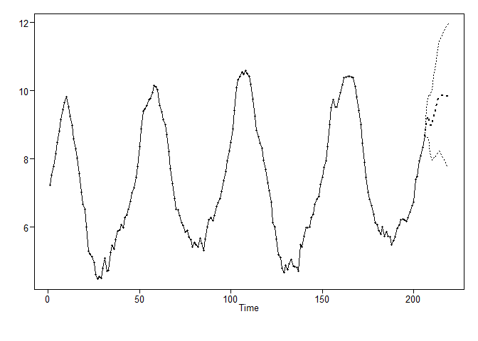

#### ASE Model Forecast

```r
#Determine ASE
fm2.ASE = mean((x_test - fm2$f)^2)
fm2.ASE
```

```
## [1] 0.2160492
```

#### Model Forecast Results - Time Realization Plot

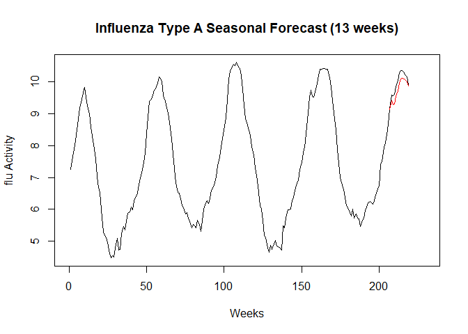

```r
#We have predicted differences .... calculate actual results
Model_Forecast2 =(x_test + fm2$f)/2

#Plot
plot(seq(1,n0,1), x_original, type="l", xlim = c(0,230), xlab= "Weeks", ylab = "flu Activity", main = "Influenza Type A Seasonal Forecast (13 weeks)")
lines(seq(nf,n0,1), Model_Forecast2, type = "l", col = "red")
```

#### Plot Comparisons: Predicted Vs. Realization Time Series

#### Compare Spectral Densities:

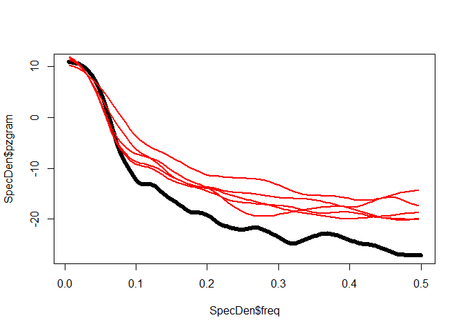

```r
sims = 5
SpecDen = parzen.wge(x, plot = "FALSE")
plot(SpecDen$freq,SpecDen$pzgram, type = "l", lwd = 6)

for( i in 1: sims)
{
  SpecDen2 = parzen.wge(gen.aruma.wge(n, phi=phi, s=s, d=d, plot = "FALSE"), plot = "FALSE")
  lines(SpecDen2$freq,SpecDen2$pzgram, lwd = 2, col = "red")
}
```

#### Compare ACF’s:

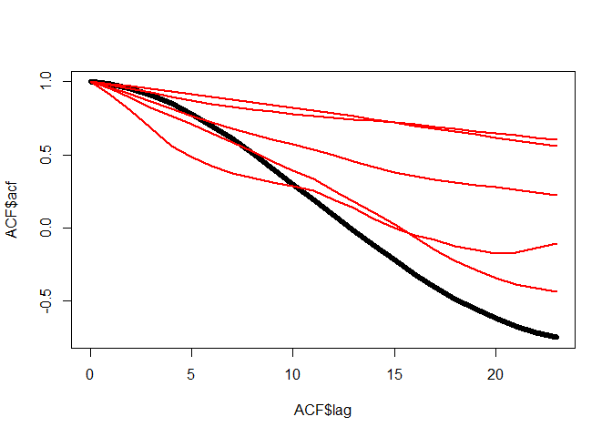

```r
sims = 5
ACF = acf(x, plot = "FALSE")
plot(ACF$lag ,ACF$acf , type = "l", lwd = 6)

for( i in 1: sims)
{
  ACF3 = acf(gen.aruma.wge(206, phi=phi, s=s, d=d, plot = "FALSE"), plot = "FALSE")
  lines(ACF3$lag ,ACF3$acf, lwd = 2, col = "red")
}
```

Compare Predicted Vs. Actual Time Series over the 13 week forecast period:

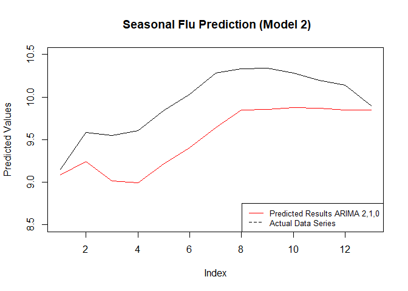

```r
name2 <- "Predicted Results ARIMA 2,1,0"

value2 <- fm2$f


color2 <-"red"

plot(x_test, type="l",
     xlim= c(1,13), ylim = c(8.5,10.5),
     ylab= "Predicted Values",
     main= " Seasonal Flu Prediction (Model 2)")
lines(seq(1,f), value2, col=color2)


# Add a legend
legend("bottomright", legend=c(name2, "Actual Data Series"),
       col=c(color2, "black"), lty=1:2, cex=0.8)
```

### PARAMETER ESTIMATION

```r
#define model 1 p, d, q estimates:
p3=1
q3=1

ARIMA_m3 = est.arma.wge(d2.x, p=p3, q=q3)
```

```
##
## Coefficients of Original polynomial:
## 0.7426
##
## Factor                 Roots                Abs Recip    System Freq
## 1-0.7426B              1.3467               0.7426       0.0000
##
##
```

AR vs. MA Factor Table Comparison:  
Invertibility checks to confirm that models does not use multiple AR and multiple MA terms in the same model.

```r
factor.wge(phi=ARIMA_m3$phi)
```

```
##
## Coefficients of Original polynomial:
## 0.7426
##
## Factor                 Roots                Abs Recip    System Freq
## 1-0.7426B              1.3467               0.7426       0.0000
##
##
```

```r
factor.wge(phi=ARIMA_m3$theta)
```

```
##
## Coefficients of Original polynomial:
## 0.5799
##
## Factor                 Roots                Abs Recip    System Freq
## 1-0.5799B              1.7245               0.5799       0.0000
##
##
```

Now that we have fit the model, let us check the residuals for white noise before proceeding any further.

### RESIDUAL CHECKS

Step 1: Visual Check of Residual Sample Correlations

Lets us look at the residuals to see if they visually to see if behavior resembles white noise:

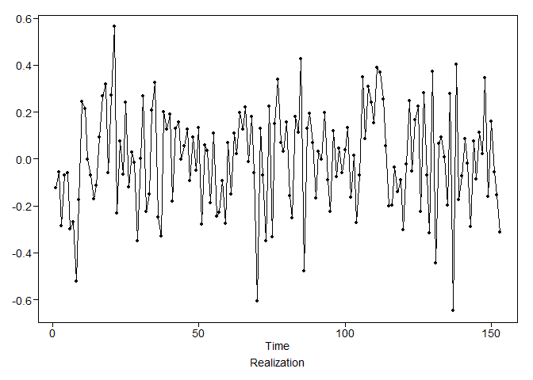

```r
plotts.wge(ARIMA_m3$res)
```

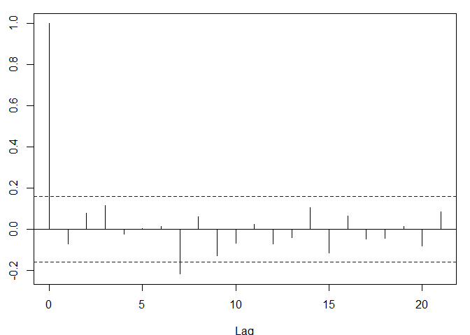

```r
acf(ARIMA_m3$res)
```

Step 2: Ljung-Box test for k=24 and K= 48

Let’s run the lJung-Box test for k=24 to determine the significance

Ljung-Box test for k=24:

```r
ljung.wge(ARIMA_m3$res,p=p3)
```

```
## Obs -0.07211623 0.07643551 0.1138588 -0.02470126 0.004736651 0.01233416 -0.2177579 0.062027 -0.1279895 -0.06818987 0.02437275 -0.07239222 -0.04121612 0.103478 -0.115548 0.06281426 -0.04721062 -0.04563527 0.01450588 -0.08321197 0.08475313 0.06968335 -0.006743432 0.0864225
```

```
## $test
## [1] "Ljung-Box test"
##
## $K
## [1] 24
##
## $chi.square
## [1] 27.35417
##
## $df
## [1] 23
##
## $pval
## [1] 0.2411923
```

Observations:  
L Jung Box Test did not reject the null hypothesis of white noise at K=24 with p-value of .24.

Let’s run the lJung-Box test for k=48 to determine the significance

Ljung-Box test for k=48:

```r
ljung.wge(ARIMA_m3$res,p=p3,K=48)
```

```
## Obs -0.07211623 0.07643551 0.1138588 -0.02470126 0.004736651 0.01233416 -0.2177579 0.062027 -0.1279895 -0.06818987 0.02437275 -0.07239222 -0.04121612 0.103478 -0.115548 0.06281426 -0.04721062 -0.04563527 0.01450588 -0.08321197 0.08475313 0.06968335 -0.006743432 0.0864225 0.05532251 -0.0801311 -0.…
```

```
## $test
## [1] "Ljung-Box test"
##
## $K
## [1] 48
##
## $chi.square
## [1] 51.04241
##
## $df
## [1] 47
##
## $pval
## [1] 0.3177827
```

Observations:  
L Jung Box Test did not reject the null hypothesis of white noise at K=48 with p-value of .31

#### Conclusion of Residual Checks:

Based on the visual sample correlation plots and the L Jung-Box Tests, the residuals from the fitted model appear to be white.